# Hands-on voriPBPK

Metrum Research Group, LLC

# Reference

Zane NR, Thakker DR. A physiologically based pharmacokinetic model for voriconazole disposition predicts intestinal first-pass metabolism in children. Clin Pharmacokinet. 2014;53: 1171â“1182  
https://link.springer.com/article/10.1007%2Fs40262-014-0181-y

# Voriconazole PBPK Model Structure

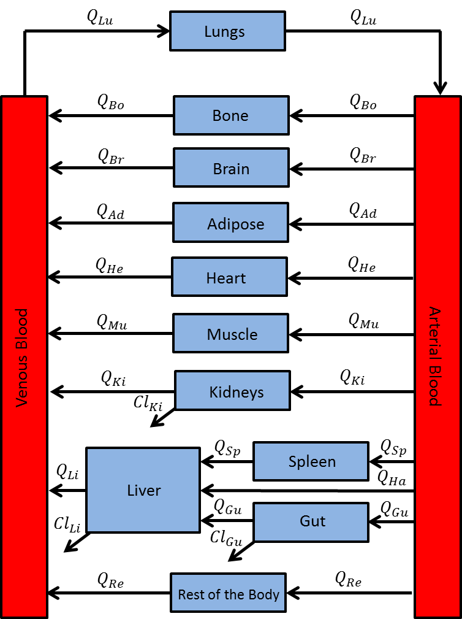

# Tasks

1. Use model `voriPBPK.cpp` to fill the model equations based on the model structure above.

**Note:** for the following tasks use `voriPBPK_script.R`

2. Simulate a 4 mg/kg voriconazole IV infusion dosing in an adult male infused over an hour twice a day for seven days. Reproduce this figure:

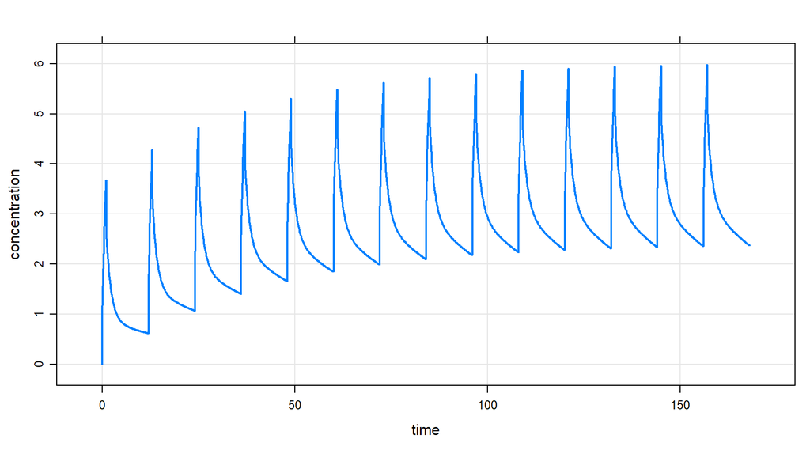

3. Compare the plasma drug concentration-time profile at steady state to the observed data in `inst/data/Adult_IV.csv` and reproduce this figure (N.B.: observed data were digitized from Zane and Thakker (2014) paper using WebPlotDigitizer https://automeris.io/WebPlotDigitizer/):

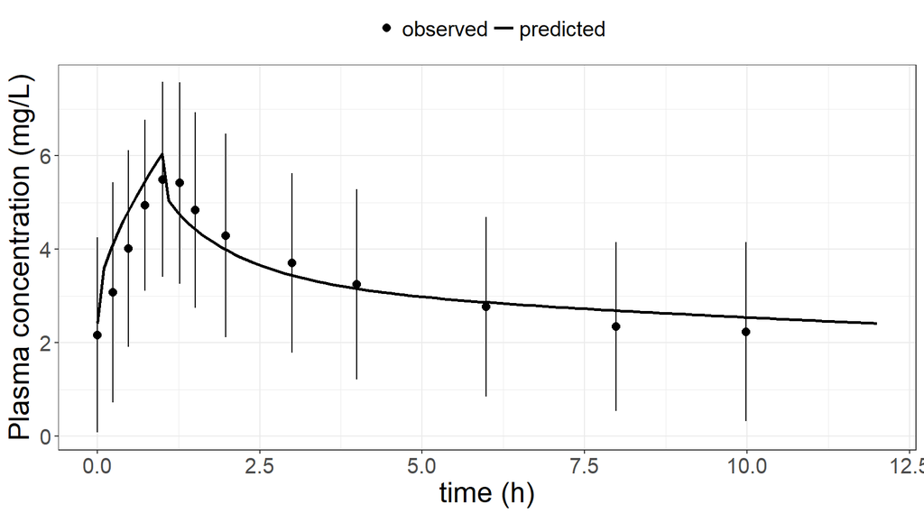

4. Generate pediatric model.
5. Simulate a 4 mg/kg voriconazole IV infusion dosing in a pediatric male subject infused at a rate of 3 mg/kg/h twice a day for seven days. Reproduce this figure:

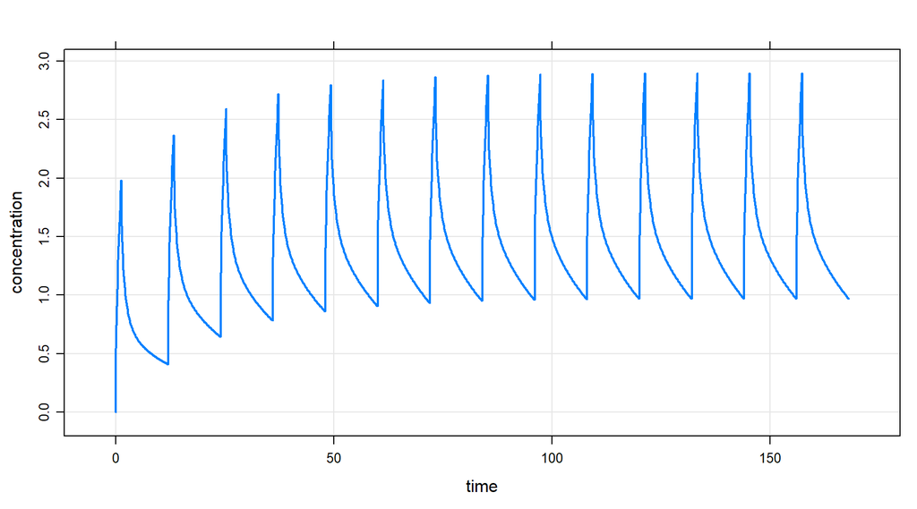

6. Compare the plasma drug concentration-time profile at steady state to the observed data in `inst/data/Pediatric_IV.csv`. Reproduce this figure:

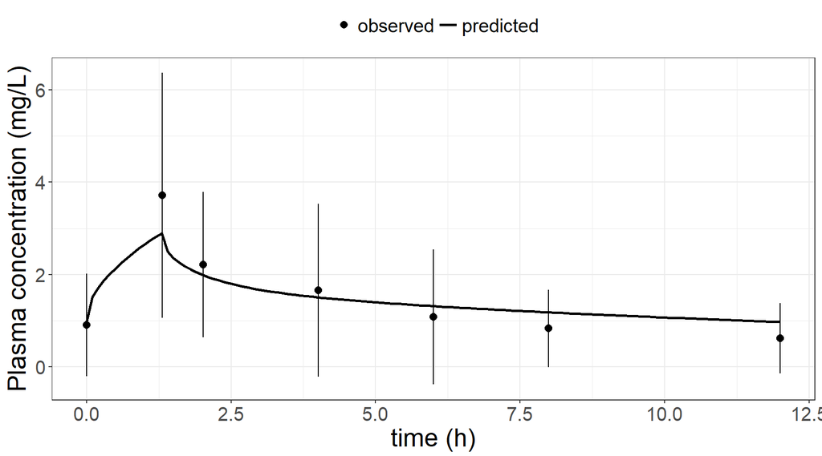